# Project: Investigate a Dataset - [Medical Appointment No Shows]

- Introduction
- Data Wrangling
- Exploratory Data Analysis
- Conclusions

## I. Introduction

### Dataset Description

This dataset collects information from 100k medical appointments in Brazil and is focused on the question of whether or not patients show up for their appointment. A number of characteristics about the patient are included in each row.

**Dataset Link**: No-show appointments

```python
# Use this cell to set up import statements for all of the packages that you
#   plan to use.

import pandas as pd
import numpy as np


import matplotlib.pyplot as plt
import seaborn as sns
%matplotlib inline


# While optional for current notebooks, if you are having trouble with visualizations,
#   remember to include a 'magic word' so that your visualizations are plotted
#   inline with the notebook. See this page for more:
#   http://ipython.readthedocs.io/en/stable/interactive/magics.html
```

## II. Data Wrangling

The data wrangling process consists of three steps:

1. Data gathering
2. Data assessment
3. Data cleaning

### 1. Data Gathering - General Properties

In this step, we will load the data and check for general properties.

```python
# Load your data and print out a few lines. What is the size of your dataframe?
#   Perform operations to inspect data types and look for instances of missing
#   or possibly errant data. There are at least 4 - 6 methods you can call on your
#   dataframe to obtain this information.
df = pd.read_csv('noshowappointments-kagglev2-may-2016.csv')
df.head()
```

|  | PatientId | AppointmentID | Gender | ScheduledDay | AppointmentDay | Age | Neighbourhood | Scholarship | Hipertension | Diabetes | Alcoholism | Handcap | SMS_received | No-show |
| --- | --- | --- | --- | --- | --- | --- | --- | --- | --- | --- | --- | --- | --- | --- |
| 0 | 2.987250e+13 | 5642903 | F | 2016-04-29T18:38:08Z | 2016-04-29T00:00:00Z | 62 | JARDIM DA PENHA | 0 | 1 | 0 | 0 | 0 | 0 | No |
| 1 | 5.589978e+14 | 5642503 | M | 2016-04-29T16:08:27Z | 2016-04-29T00:00:00Z | 56 | JARDIM DA PENHA | 0 | 0 | 0 | 0 | 0 | 0 | No |
| 2 | 4.262962e+12 | 5642549 | F | 2016-04-29T16:19:04Z | 2016-04-29T00:00:00Z | 62 | MATA DA PRAIA | 0 | 0 | 0 | 0 | 0 | 0 | No |
| 3 | 8.679512e+11 | 5642828 | F | 2016-04-29T17:29:31Z | 2016-04-29T00:00:00Z | 8 | PONTAL DE CAMBURI | 0 | 0 | 0 | 0 | 0 | 0 | No |
| 4 | 8.841186e+12 | 5642494 | F | 2016-04-29T16:07:23Z | 2016-04-29T00:00:00Z | 56 | JARDIM DA PENHA | 0 | 1 | 1 | 0 | 0 | 0 | No |

```python
# Check the size of the dataframe.
print('The dataframe has {} rows and {} columns.'.format(df.shape[0], df.shape[1]))
```

```
The dataframe has 110527 rows and 14 columns.
```

```python
# Check the data types of the dataframe.
df.info()
```

```
<class 'pandas.core.frame.DataFrame'>
RangeIndex: 110527 entries, 0 to 110526
Data columns (total 14 columns):
 #   Column          Non-Null Count   Dtype
---  ------          --------------   -----
 0   PatientId       110527 non-null  float64
 1   AppointmentID   110527 non-null  int64
 2   Gender          110527 non-null  object
 3   ScheduledDay    110527 non-null  object
 4   AppointmentDay  110527 non-null  object
 5   Age             110527 non-null  int64
 6   Neighbourhood   110527 non-null  object
 7   Scholarship     110527 non-null  int64
 8   Hipertension    110527 non-null  int64
 9   Diabetes        110527 non-null  int64
 10  Alcoholism      110527 non-null  int64
 11  Handcap         110527 non-null  int64
 12  SMS_received    110527 non-null  int64
 13  No-show         110527 non-null  object
dtypes: float64(1), int64(8), object(5)
memory usage: 11.8+ MB
```

### 2. Data Assessment - Quality and Tidiness Issues

In this step, we will assess the data for quality and tidiness issues.

```python
df.dtypes
```

```
PatientId         float64
AppointmentID       int64
Gender             object
ScheduledDay       object
AppointmentDay     object
Age                 int64
Neighbourhood      object
Scholarship         int64
Hipertension        int64
Diabetes            int64
Alcoholism          int64
Handcap             int64
SMS_received        int64
No-show            object
dtype: object
```

With the above steps, we can identify the following issues:

**Quality Issues**

1. **PatientId** and **AppointmentID** should be string instead of float.
2. **ScheduledDay** and **AppointmentDay** should be datetime instead of string.
3. Rename **No-show** column to **No_show**.
4. Correct column names: **Hipertension** to **Hypertension**, **Handcap** to **Handicap**

```python
# Check summary statistics of the dataframe.
df.describe()
```

|  | PatientId | AppointmentID | Age | Scholarship | Hipertension | Diabetes | Alcoholism | Handcap | SMS_received |
| --- | --- | --- | --- | --- | --- | --- | --- | --- | --- |
| count | 1.105270e+05 | 1.105270e+05 | 110527.000000 | 110527.000000 | 110527.000000 | 110527.000000 | 110527.000000 | 110527.000000 | 110527.000000 |
| mean | 1.474963e+14 | 5.675305e+06 | 37.088874 | 0.098266 | 0.197246 | 0.071865 | 0.030400 | 0.022248 | 0.321026 |
| std | 2.560949e+14 | 7.129575e+04 | 23.110205 | 0.297675 | 0.397921 | 0.258265 | 0.171686 | 0.161543 | 0.466873 |
| min | 3.921784e+04 | 5.030230e+06 | -1.000000 | 0.000000 | 0.000000 | 0.000000 | 0.000000 | 0.000000 | 0.000000 |
| 25% | 4.172614e+12 | 5.640286e+06 | 18.000000 | 0.000000 | 0.000000 | 0.000000 | 0.000000 | 0.000000 | 0.000000 |
| 50% | 3.173184e+13 | 5.680573e+06 | 37.000000 | 0.000000 | 0.000000 | 0.000000 | 0.000000 | 0.000000 | 0.000000 |
| 75% | 9.439172e+13 | 5.725524e+06 | 55.000000 | 0.000000 | 0.000000 | 0.000000 | 0.000000 | 0.000000 | 1.000000 |
| max | 9.999816e+14 | 5.790484e+06 | 115.000000 | 1.000000 | 1.000000 | 1.000000 | 1.000000 | 4.000000 | 1.000000 |

With the about output, we can see that there are some quality and tidiness issues in the dataset. We will list them below:

**Quality Issues** - The `Age` column has negative values. - The `Age` column has a maximum value of 115.

```python
# Check the row with the negative age.
df[df['Age'] < 0]
```

|  | PatientId | AppointmentID | Gender | ScheduledDay | AppointmentDay | Age | Neighbourhood | Scholarship | Hipertension | Diabetes | Alcoholism | Handcap | SMS_received | No-show |
| --- | --- | --- | --- | --- | --- | --- | --- | --- | --- | --- | --- | --- | --- | --- |
| 99832 | 4.659432e+14 | 5775010 | F | 2016-06-06T08:58:13Z | 2016-06-06T00:00:00Z | -1 | ROMÃO | 0 | 0 | 0 | 0 | 0 | 0 | No |

We can remove the row with the negative age value. But, we will keep the row with the age value of 115, because it is possible that the patient is 115 years old. I think we can remove the row with negative age value. Because removing 1 of 110527 rows will not affect the analysis.

```python
# Check duplicate rows.
print('There are {} duplicated rows.'.format(df.duplicated().sum()))
```

```
There are 0 duplicated rows.
```

```python
# Check duplicate patient IDs.
print('There are {} duplicated patient IDs.'.format(df['PatientId'].duplicated().sum()))
```

```
There are 48228 duplicated patient IDs.
```

```python
# Top 10 patient IDs with the most appointments.
df['PatientId'].value_counts().head(10)
```

```
PatientId
8.221459e+14    88
9.963767e+10    84
2.688613e+13    70
3.353478e+13    65
6.264199e+12    62
2.584244e+11    62
8.713749e+14    62
7.579746e+13    62
6.684488e+13    57
8.722785e+11    55
Name: count, dtype: int64
```

```python
# Check the number of unique patient IDs.
print('There are {} unique patient IDs.'.format(df['PatientId'].nunique()))
```

```
There are 62299 unique patient IDs.
```

From about result, we can see:

- A patient can have multiple appointments
- Top 10 patients with the most appointments
- Has 62299 unique patients

```python
# Check duplicate appointment IDs.
print('There are {} duplicated appointment IDs.'.format(df['AppointmentID'].duplicated().sum()))
```

```
There are 0 duplicated appointment IDs.
```

```python
# Check for missing values.
df.isnull().sum()
```

```
PatientId         0
AppointmentID     0
Gender            0
ScheduledDay      0
AppointmentDay    0
Age               0
Neighbourhood     0
Scholarship       0
Hipertension      0
Diabetes          0
Alcoholism        0
Handcap           0
SMS_received      0
No-show           0
dtype: int64
```

```python
# Show no missing values in the dataframe.
print('There are {} missing values in the dataframe.'.format(df.isnull().sum().sum()))
```

```
There are 0 missing values in the dataframe.
```

The dataset has no missing values.

```python
# Check number of unique values in each column.
df.nunique()
```

```
PatientId          62299
AppointmentID     110527
Gender                 2
ScheduledDay      103549
AppointmentDay        27
Age                  104
Neighbourhood         81
Scholarship            2
Hipertension           2
Diabetes               2
Alcoholism             2
Handcap                5
SMS_received           2
No-show                2
dtype: int64
```

```python
# List unique values in each column.
for col in df.columns:
    print(col)
    print(df[col].unique())
    print()
```

```
PatientId
[2.98724998e+13 5.58997777e+14 4.26296230e+12 ... 7.26331493e+13
 9.96997666e+14 1.55766317e+13]

AppointmentID
[5642903 5642503 5642549 ... 5630692 5630323 5629448]

Gender
['F' 'M']

ScheduledDay
['2016-04-29T18:38:08Z' '2016-04-29T16:08:27Z' '2016-04-29T16:19:04Z' ...
 '2016-04-27T16:03:52Z' '2016-04-27T15:09:23Z' '2016-04-27T13:30:56Z']

AppointmentDay
['2016-04-29T00:00:00Z' '2016-05-03T00:00:00Z' '2016-05-10T00:00:00Z'
 '2016-05-17T00:00:00Z' '2016-05-24T00:00:00Z' '2016-05-31T00:00:00Z'
 '2016-05-02T00:00:00Z' '2016-05-30T00:00:00Z' '2016-05-16T00:00:00Z'
 '2016-05-04T00:00:00Z' '2016-05-19T00:00:00Z' '2016-05-12T00:00:00Z'
 '2016-05-06T00:00:00Z' '2016-05-20T00:00:00Z' '2016-05-05T00:00:00Z'
 '2016-05-13T00:00:00Z' '2016-05-09T00:00:00Z' '2016-05-25T00:00:00Z'
 '2016-05-11T00:00:00Z' '2016-05-18T00:00:00Z' '2016-05-14T00:00:00Z'
 '2016-06-02T00:00:00Z' '2016-06-03T00:00:00Z' '2016-06-06T00:00:00Z'
 '2016-06-07T00:00:00Z' '2016-06-01T00:00:00Z' '2016-06-08T00:00:00Z']

Age
[ 62  56   8  76  23  39  21  19  30  29  22  28  54  15  50  40  46   4
  13  65  45  51  32  12  61  38  79  18  63  64  85  59  55  71  49  78
  31  58  27   6   2  11   7   0   3   1  69  68  60  67  36  10  35  20
  26  34  33  16  42   5  47  17  41  44  37  24  66  77  81  70  53  75
  73  52  74  43  89  57  14   9  48  83  72  25  80  87  88  84  82  90
  94  86  91  98  92  96  93  95  97 102 115 100  99  -1]

Neighbourhood
['JARDIM DA PENHA' 'MATA DA PRAIA' 'PONTAL DE CAMBURI' 'REPÚBLICA'
 'GOIABEIRAS' 'ANDORINHAS' 'CONQUISTA' 'NOVA PALESTINA' 'DA PENHA'
 'TABUAZEIRO' 'BENTO FERREIRA' 'SÃO PEDRO' 'SANTA MARTHA' 'SÃO CRISTÓVÃO'
 'MARUÍPE' 'GRANDE VITÓRIA' 'SÃO BENEDITO' 'ILHA DAS CAIEIRAS'
 'SANTO ANDRÉ' 'SOLON BORGES' 'BONFIM' 'JARDIM CAMBURI' 'MARIA ORTIZ'
 'JABOUR' 'ANTÔNIO HONÓRIO' 'RESISTÊNCIA' 'ILHA DE SANTA MARIA'
```

[output cut: 18 more lines]

```

Diabetes
[0 1]

Alcoholism
[0 1]

Handcap
[0 1 2 3 4]

SMS_received
[0 1]

No-show
['No' 'Yes']
```

With the about output, we can separate the dataset into two type of data:

- Categorical data: `Gender`, `Neighbourhood`, `Scholarship`, `Hipertension`, `Diabetes`, `Alcoholism`, `Handcap`, `SMS_received`, `No-show`
- Quantitative data: `PatientId`, `AppointmentID`, `Age`, `ScheduledDay`, `AppointmentDay`

With Catagorical data, we can see:

- `Gender` has two values: `F` and `M`
- `Neighbourhood` has 81 unique values
- `Scholarship` has two values: `0` and `1`
- `Hipertension` has two values: `0` and `1`
- `Diabetes` has two values: `0` and `1`
- `Alcoholism` has two values: `0` and `1`
- `Handcap` has five values: `0`, `1`, `2`, `3`, `4`
- `SMS_received` has two values: `0` and `1`
- `No-show` has two values: `No` and `Yes`

### 3. Data Cleaning

We will clean the data in this step. We will fix the quality and tidiness issues that we identified in the previous step.

```python
# After discussing the structure of the data and any problems that need to be
#   cleaned, perform those cleaning steps in the second part of this section.

# 1. Drop the row with the negative age.
df.drop(df[df['Age'] < 0].index, inplace=True)
```

```python
# Check if the row with the negative age is dropped.
df[df['Age'] < 0]
```

|  | PatientId | AppointmentID | Gender | ScheduledDay | AppointmentDay | Age | Neighbourhood | Scholarship | Hipertension | Diabetes | Alcoholism | Handcap | SMS_received | No-show |
| --- | --- | --- | --- | --- | --- | --- | --- | --- | --- | --- | --- | --- | --- | --- |

```python
# 2. **PatientId** and **AppointmentID** should be string instead of float.
df['PatientId'] = df['PatientId'].astype(str)
df['AppointmentID'] = df['AppointmentID'].astype(str)
```

```python
# Check if **PatientId** and **AppointmentID** are string.
df.dtypes
```

```
PatientId         object
AppointmentID     object
Gender            object
ScheduledDay      object
AppointmentDay    object
Age                int64
Neighbourhood     object
Scholarship        int64
Hipertension       int64
Diabetes           int64
Alcoholism         int64
Handcap            int64
SMS_received       int64
No-show           object
dtype: object
```

```python
# 3. Convert **ScheduledDay** and **AppointmentDay** to datetime.
df['ScheduledDay'] = pd.to_datetime(df['ScheduledDay'])
df['AppointmentDay'] = pd.to_datetime(df['AppointmentDay'])
```

```python
# Check if **ScheduledDay** and **AppointmentDay** are datetime.
df.dtypes
```

```
PatientId                      object
AppointmentID                  object
Gender                         object
ScheduledDay      datetime64[ns, UTC]
AppointmentDay    datetime64[ns, UTC]
Age                             int64
Neighbourhood                  object
Scholarship                     int64
Hipertension                    int64
Diabetes                        int64
Alcoholism                      int64
Handcap                         int64
SMS_received                    int64
No-show                        object
dtype: object
```

```python
# 5. Correct column names: **Hipertension** to **Hypertension**, **Handcap** to **Handicap**
df.rename(columns={'Hipertension': 'Hypertension', 'Handcap': 'Handicap'}, inplace=True)
```

```python
# 5. Replace **No_show** with **Showed_up** and **Yes** with **No**.
df.rename(columns={'No-show': 'Showed_up'}, inplace=True)
df['Showed_up'] = df['Showed_up'].apply(lambda x : 'Yes' if x =='No' else 'No' )
```

```python
# Check if column names are corrected.
df.head()
```

|  | PatientId | AppointmentID | Gender | ScheduledDay | AppointmentDay | Age | Neighbourhood | Scholarship | Hypertension | Diabetes | Alcoholism | Handicap | SMS_received | Showed_up |
| --- | --- | --- | --- | --- | --- | --- | --- | --- | --- | --- | --- | --- | --- | --- |
| 0 | 29872499824296.0 | 5642903 | F | 2016-04-29 18:38:08+00:00 | 2016-04-29 00:00:00+00:00 | 62 | JARDIM DA PENHA | 0 | 1 | 0 | 0 | 0 | 0 | Yes |
| 1 | 558997776694438.0 | 5642503 | M | 2016-04-29 16:08:27+00:00 | 2016-04-29 00:00:00+00:00 | 56 | JARDIM DA PENHA | 0 | 0 | 0 | 0 | 0 | 0 | Yes |
| 2 | 4262962299951.0 | 5642549 | F | 2016-04-29 16:19:04+00:00 | 2016-04-29 00:00:00+00:00 | 62 | MATA DA PRAIA | 0 | 0 | 0 | 0 | 0 | 0 | Yes |
| 3 | 867951213174.0 | 5642828 | F | 2016-04-29 17:29:31+00:00 | 2016-04-29 00:00:00+00:00 | 8 | PONTAL DE CAMBURI | 0 | 0 | 0 | 0 | 0 | 0 | Yes |
| 4 | 8841186448183.0 | 5642494 | F | 2016-04-29 16:07:23+00:00 | 2016-04-29 00:00:00+00:00 | 56 | JARDIM DA PENHA | 0 | 1 | 1 | 0 | 0 | 0 | Yes |

```python
# 6. Create DayOfWeek column from AppointmentDay.
df['DayOfWeek'] = pd.to_datetime(df['AppointmentDay']).dt.day_name()
```

```python
# Check if column names are corrected.
df.head()
```

|  | PatientId | AppointmentID | Gender | ScheduledDay | AppointmentDay | Age | Neighbourhood | Scholarship | Hypertension | Diabetes | Alcoholism | Handicap | SMS_received | Showed_up | DayOfWeek |
| --- | --- | --- | --- | --- | --- | --- | --- | --- | --- | --- | --- | --- | --- | --- | --- |
| 0 | 29872499824296.0 | 5642903 | F | 2016-04-29 18:38:08+00:00 | 2016-04-29 00:00:00+00:00 | 62 | JARDIM DA PENHA | 0 | 1 | 0 | 0 | 0 | 0 | Yes | Friday |
| 1 | 558997776694438.0 | 5642503 | M | 2016-04-29 16:08:27+00:00 | 2016-04-29 00:00:00+00:00 | 56 | JARDIM DA PENHA | 0 | 0 | 0 | 0 | 0 | 0 | Yes | Friday |
| 2 | 4262962299951.0 | 5642549 | F | 2016-04-29 16:19:04+00:00 | 2016-04-29 00:00:00+00:00 | 62 | MATA DA PRAIA | 0 | 0 | 0 | 0 | 0 | 0 | Yes | Friday |
| 3 | 867951213174.0 | 5642828 | F | 2016-04-29 17:29:31+00:00 | 2016-04-29 00:00:00+00:00 | 8 | PONTAL DE CAMBURI | 0 | 0 | 0 | 0 | 0 | 0 | Yes | Friday |
| 4 | 8841186448183.0 | 5642494 | F | 2016-04-29 16:07:23+00:00 | 2016-04-29 00:00:00+00:00 | 56 | JARDIM DA PENHA | 0 | 1 | 1 | 0 | 0 | 0 | Yes | Friday |

```python
# Update the values in Gender, Scholarship, Diabetes, Alcoholism, Hypertension, Handicap, and SMS_received to readable values.

df["Gender"] = df.Gender.astype("category")
df["Gender"] = df.Gender.cat.rename_categories(['Female','Male'])

df["Scholarship"] = df.Scholarship.astype("category")
df["Scholarship"] = df.Scholarship.cat.rename_categories(['No','Yes'])

df["Diabetes"] = df.Diabetes.astype("category")
df["Diabetes"] = df.Diabetes.cat.rename_categories(['No','Yes'])

df["Alcoholism"] = df.Alcoholism.astype("category")
df["Alcoholism"] = df.Alcoholism.cat.rename_categories(['No','Yes'])

df["Hypertension"] = df.Hypertension.astype("category")
df["Hypertension"] = df.Hypertension.cat.rename_categories(['No','Yes'])

df["Handicap"] = df.Handicap.astype("category")
df["Handicap"] = df.Handicap.cat.rename_categories(['Handicap L0', 'Handicap L1', 'Handicap L2', 'Handicap L3', 'Handicap L4'])

df["SMS_received"] = df.SMS_received.astype("category")
df["SMS_received"] = df.SMS_received.cat.rename_categories(['No','Yes'])

# Check if the values are updated.
df.head()
```

|  | PatientId | AppointmentID | Gender | ScheduledDay | AppointmentDay | Age | Neighbourhood | Scholarship | Hypertension | Diabetes | Alcoholism | Handicap | SMS_received | Showed_up | DayOfWeek |
| --- | --- | --- | --- | --- | --- | --- | --- | --- | --- | --- | --- | --- | --- | --- | --- |
| 0 | 29872499824296.0 | 5642903 | Female | 2016-04-29 18:38:08+00:00 | 2016-04-29 00:00:00+00:00 | 62 | JARDIM DA PENHA | No | Yes | No | No | Handicap L0 | No | Yes | Friday |
| 1 | 558997776694438.0 | 5642503 | Male | 2016-04-29 16:08:27+00:00 | 2016-04-29 00:00:00+00:00 | 56 | JARDIM DA PENHA | No | No | No | No | Handicap L0 | No | Yes | Friday |
| 2 | 4262962299951.0 | 5642549 | Female | 2016-04-29 16:19:04+00:00 | 2016-04-29 00:00:00+00:00 | 62 | MATA DA PRAIA | No | No | No | No | Handicap L0 | No | Yes | Friday |
| 3 | 867951213174.0 | 5642828 | Female | 2016-04-29 17:29:31+00:00 | 2016-04-29 00:00:00+00:00 | 8 | PONTAL DE CAMBURI | No | No | No | No | Handicap L0 | No | Yes | Friday |
| 4 | 8841186448183.0 | 5642494 | Female | 2016-04-29 16:07:23+00:00 | 2016-04-29 00:00:00+00:00 | 56 | JARDIM DA PENHA | No | Yes | Yes | No | Handicap L0 | No | Yes | Friday |

```python
# Create df with limit patients of top 10 neighborhood with most appointments.
df_top10_neighborhood = df[df['Neighbourhood'].isin(df['Neighbourhood'].value_counts().nlargest(10).index)]
```

```python
# Create no showup dataframe.
df_no_showup = df[df['Showed_up'] == 'No']
```

## III. Exploratory Data Analysis

```python
def visualizeShowUpRate(df, feature, figsize=(10,10)):
    """
    Visualize the show-up rate by a particular feature or column.

    Parameters:
    df (pandas.DataFrame): The DataFrame to visualize the show-up rate.
    feature (str): The column name to visualize the show-up rate.
    figsize (tuple): The size of the figure. Default is (10,10).

    Returns:
    result_dict (dict): A dictionary with the total number per category, show up rates, and the plot.
    """
    if feature not in df.columns or 'Showed_up' not in df.columns:
        raise ValueError("The specified column does not exist in the DataFrame.")

    # groupy feature and display value count of showed_up
    values = pd.DataFrame(df.groupby(feature).Showed_up.value_counts())

    # groupy feature and calculate the showed_up rate.
    plot_values = df.groupby(feature).Showed_up.value_counts(normalize=True)

    # unstack and convert showed up rates to percentages by multiplying by 100
    plot_values = plot_values.unstack().mul(100).round()

    # visualize the plot_values
    ax = plot_values.plot(kind='bar', figsize=figsize)
    plt.title(f'Appointment Show up Rate of Non-{feature}/{feature} Patients')
    plt.ylabel('Show up Rate(%)')
    plt.xlabel(f'{feature}')
    plt.xticks(rotation= 0)
    plt.show()

    result_dict = {'Total number per category': values, 'Show up rates': plot_values, 'Plot': ax}
    return result_dict

def generateBarChartByShowup(df, col, showedUp='Showed_up', normalize='index', figsize=(10,5), rotation=0):
    """
    Generate a bar plot for the frequency table based on show or no show status.

    Parameters:
    df (pandas.DataFrame): The DataFrame to plot.
    col (str): The column name to group by.
    Showed_up (str): The column name for no. Default is 'Showed_up'.
    normalize (str): The parameter to normalize the cross tabulation. Default is 'index'.
    figsize (tuple): The size of the figure. Default is (10,5).
    rotation (int): The rotation angle for the x-axis labels. Default is 0.

    Returns:
    dfByCol (pandas.DataFrame): The DataFrame of the frequency table.
    """
    if col not in df.columns or showedUp not in df.columns:
        raise ValueError("The specified column does not exist in the DataFrame.")

    dfByCol = pd.crosstab(df[col], df[showedUp], normalize=normalize)
    dfByCol = dfByCol[dfByCol.columns[::-1]]  # Reverse the column order
    dfByCol = np.round((dfByCol * 100), decimals=2)
    ax = dfByCol.plot.bar(figsize=figsize)
    vals = ax.get_yticks()
    ax.set_yticks(vals)
    ax.set_yticklabels(['{:3.0f}%'.format(x) for x in vals])
    ax.set_xticklabels(dfByCol.index, rotation=rotation, fontsize=15)
    ax.set_title('\nShowUp vs. No ShowUp by ' + dfByCol.index.name + ' (%)\n', fontsize=15)
    ax.set_xlabel(dfByCol.index.name, fontsize=12)
    ax.set_ylabel('(%)', fontsize=12)
    ax.legend(loc='upper left', bbox_to_anchor=(1.0,1.0), fontsize=12)
    rects = ax.patches

    # Add Data Labels
    for rect in rects:
        height = rect.get_height()
        ax.text(rect.get_x() + rect.get_width()/2, height + 2, str(height)+'%', ha='center', va='bottom', fontsize=12)

    return dfByCol

def generatePieChartAppointmentByCol(df, col, figsize=(10,10)):
    """
    Generate a pie chart for the proportion of a variable per appointment.

    Parameters:
    df (pandas.DataFrame): The DataFrame to plot.
    col (str): The column name to calculate proportions.
    figsize (tuple): The size of the figure. Default is (10,10).

    Returns:
    dfPie (pandas.Series): The Series of the proportions.
    """
    if col not in df.columns:
        raise ValueError("The specified column does not exist in the DataFrame.")

    dfPie = df[col].value_counts()
    ax = dfPie.plot.pie(figsize=figsize, autopct='%1.2f%%', fontsize=12)
    ax.set_title(col + ' Per appointment (%)\n', fontsize=15)
    return np.round(dfPie/df.shape[0]*100,2)

def numberOfPatientsByCol(df, col, figsize=(10,10)):
    """
    Generate a pie chart for the proportion of unique patients based on a variable.

    Parameters:
    df (pandas.DataFrame): The DataFrame to plot.
    col (str): The column name to calculate proportions.
    figsize (tuple): The size of the figure. Default is (10,10).

    Returns:
    PatID_Count (pandas.DataFrame): The DataFrame of the proportions.
    """
    if col not in df.columns:
        raise ValueError("The specified column does not exist in the DataFrame.")

    patientIdCount = pd.pivot_table(df, index=col, values='PatientId', aggfunc=lambda x: len(x.unique()))
    ax = patientIdCount.plot.pie(figsize=figsize, autopct='%1.2f%%', subplots=True, fontsize=12, legend=False)
    plt.title(col + ' Per patient (%)\n', fontsize=15)
    return np.round(patientIdCount/sum(patientIdCount['PatientId'])*100,2)

def showUpBy2Cols(df, col1, col2, figsize=(10,5)):
    """
    Generate a horizontal stacked bar chart for the proportion of no-shows based on two variables.

    Parameters:
    df (pandas.DataFrame): The DataFrame to plot.
    col1 (str): The first column name to calculate proportions.
    col2 (str): The second column name to calculate proportions.
    figsize (tuple): The size of the figure. Default is (10,5).

    Returns:
    Freq_df (pandas.DataFrame): The DataFrame of the proportions.
    """
    if col1 not in df.columns or col2 not in df.columns:
        raise ValueError("The specified column does not exist in the DataFrame.")

    result = pd.crosstab(df[col1], columns=df[col2], normalize='index')
    result = np.round(result * 100,2)
    ax = result.plot.barh(stacked=True, figsize=figsize)
    ax.set_title('\nShowUp by ' + str(col1) + ' & '+ str(col2) + ' (%)\n', fontsize=15)
    ax.set_ylabel(result.index.name, fontsize=12)
    ax.set_xlabel('(%)', fontsize=12)
    vals = ax.get_xticks()
    ax.set_xticks(vals)
    ax.set_xticklabels(['{:3.0f}%'.format(x) for x in vals])
    ax.tick_params(axis='both', which='major', labelsize=12)
    ax.legend(loc='upper left', bbox_to_anchor=(1.0,1.0), fontsize=12)
    return result

def recurringPatientPerBy2Cols(df, col1, col2, figsize=(10,5)):
    """
    Generate a bar chart for the percentage of recurring patients based on two variables.

    Parameters:
    df (pandas.DataFrame): The DataFrame to plot.
    col1 (str): The first column name to calculate proportions.
    col2 (str): The second column name to calculate proportions.
    figsize (tuple): The size of the figure. Default is (10,5).

    Returns:
    result (pandas.DataFrame): The DataFrame of the proportions.
    """
    if col1 not in df.columns or col2 not in df.columns:
        raise ValueError("The specified column does not exist in the DataFrame.")

    patientIdCount = pd.pivot_table(df, index=col1, columns=col2, values='PatientId', aggfunc=lambda x: len(x.unique()))
    appointmentIdCount = pd.pivot_table(df, index=col1, columns=col2, values='AppointmentID', aggfunc='count')
    result = np.round((1 - patientIdCount/appointmentIdCount)*100,2)
    ax = result.plot.bar(figsize=figsize)
    vals = ax.get_yticks()
    ax.set_yticks(vals)
    ax.set_yticklabels(['{:3.0f}%'.format(x) for x in vals])
    ax.set_xticklabels(result.index, rotation=0, fontsize=15)
    ax.set_title('\nRecurring Patients (%)\n', fontsize=15)
    ax.set_xlabel(result.index.name, fontsize=12)
    ax.set_ylabel('(%)', fontsize=12)
    ax.legend(loc='upper left', bbox_to_anchor=(1.0,1.0), fontsize=12)
    rects = ax.patches

    # Add Data Labels
    for rect in rects:
        height = rect.get_height()
        ax.text(rect.get_x() + rect.get_width()/2, height + 2, str(height)+'%', ha='center', va='bottom', fontsize=12)

    return result
```

### Research Question 1 - What are the percentages of patients who showed up and those who did not?

```
Showed_up
Yes    79.81
No     20.19
Name: count, dtype: float64
```

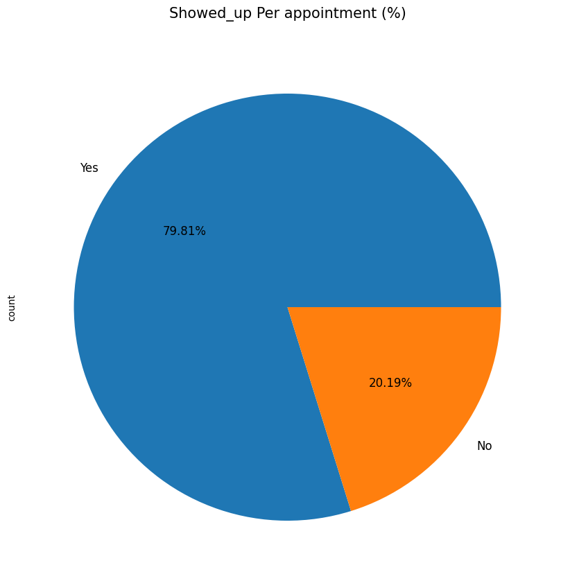

```python
# Use this, and more code cells, to explore your data. Don't forget to add
#   Markdown cells to document your observations and findings.

# 1. What is the overall appointment show-up vs. no show-up rate?
generatePieChartAppointmentByCol(df, 'Showed_up')
```

With 110527 appointments, 79.81% of patients showed up and 20.19% of patients did not show up.

### Research Question 2

What are the distributions of different categories within each variable and the show-up rates for each category?

**Next Steps:**

- Analyze the distribution of different categories within each variable.
- Calculate the show-up rates for each category within the variables.

#### 1. Gender

| Gender | PatientId |
| --- | --- |
| Female | 64.28 |
| Male | 35.72 |

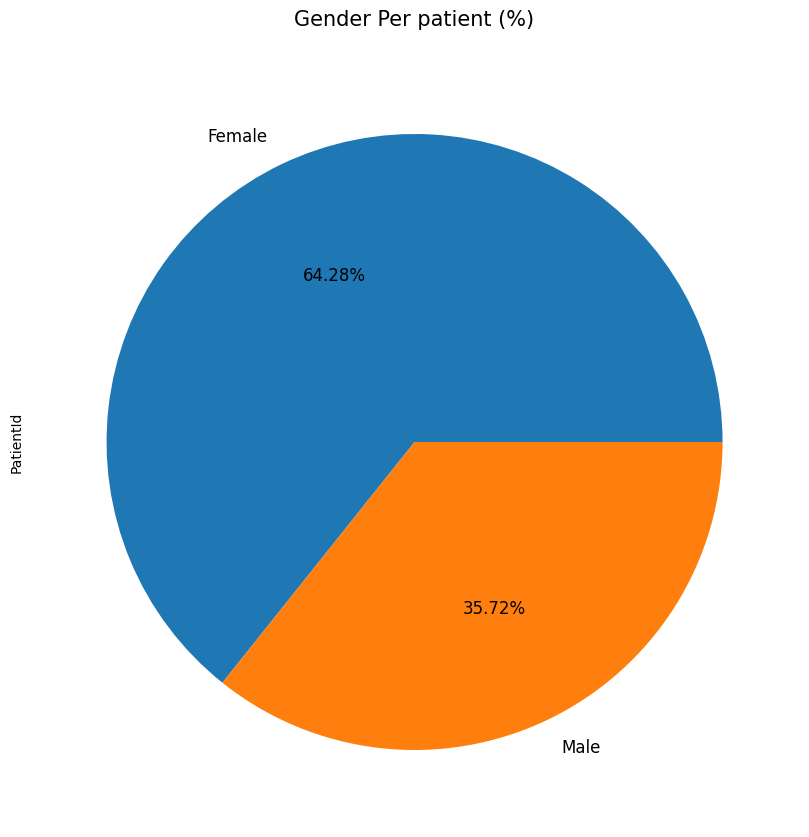

```python
# Number of patients by percentage
numberOfPatientsByCol(df, 'Gender')
```

```
Gender
Female    65.0
Male      35.0
Name: count, dtype: float64
```

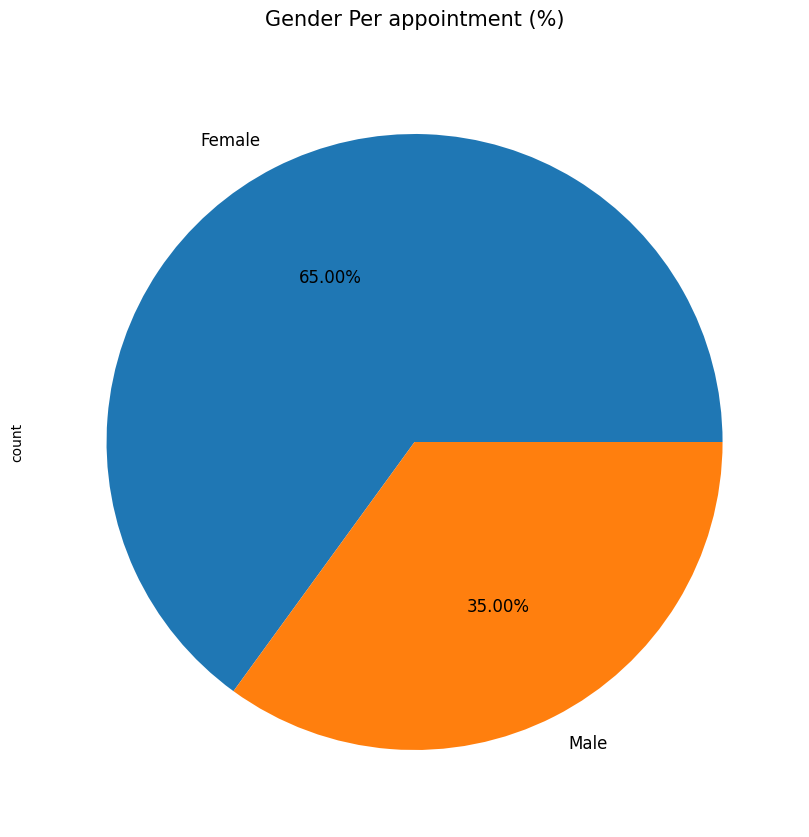

```python
# Which gender has a higher show-up rate?
generatePieChartAppointmentByCol(df, "Gender")
```

| Showed_up Gender | Yes | No |
| --- | --- | --- |
| Female | 79.69 | 20.31 |
| Male | 80.03 | 19.97 |

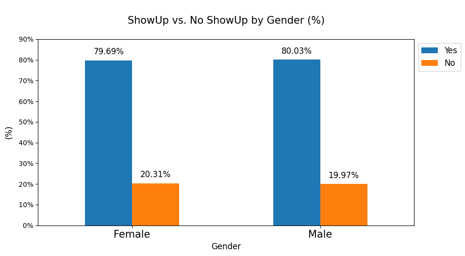

```python
# Visualize no showup and show up by gender using bar chart
generateBarChartByShowup(df, "Gender")
```

With the above charts, we can see:

- The overall count of female patients is higher than that of male patients.
- The number of appointments with female patients exceeds those with male patients.
- The show-up rate for appointments, when calculated per number of appointments, is marginally higher for male patients compared to female patients.

#### 2. Age

```
AgeGroup
51-60     14.17
0-10      13.76
31-40     13.62
41-50     13.05
21-30     12.47
11-20     11.85
61-70     10.12
71-80      5.18
81-90      2.30
91-115     0.28
Name: count, dtype: float64
```

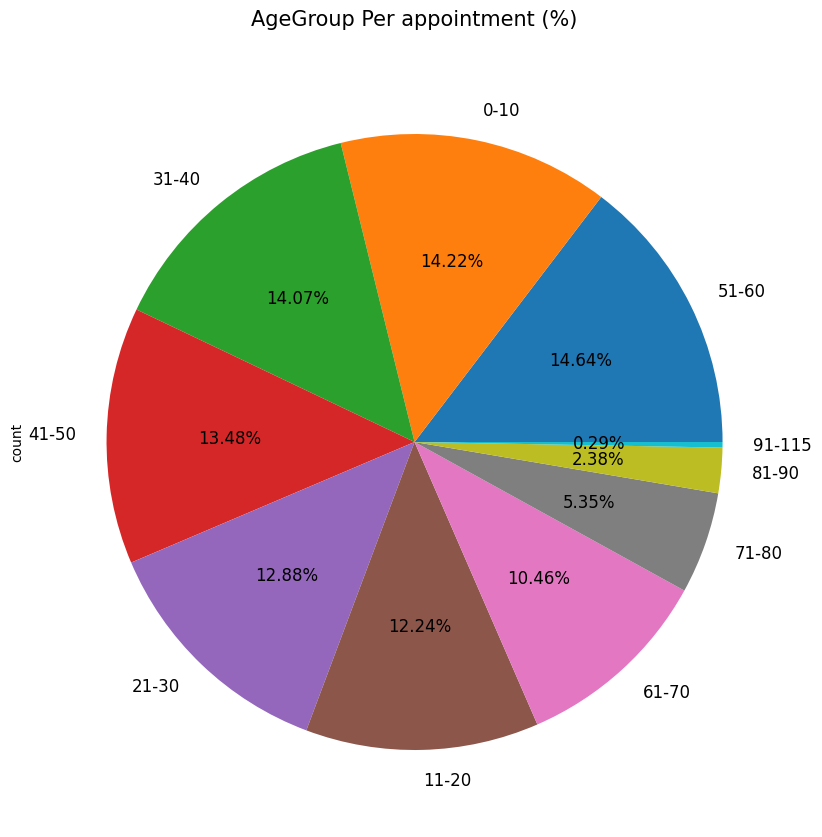

```python
# Define a new coloumn "AgeGroup" to group patients by age
df['AgeGroup'] = pd.cut(df['Age'], bins=[0, 10, 20, 30, 40, 50, 60, 70, 80, 90, 115],
                        labels=['0-10', '11-20', '21-30', '31-40', '41-50',
                                '51-60', '61-70', '71-80', '81-90', '91-115'])
# Percentage of patients by age
generatePieChartAppointmentByCol(df, 'AgeGroup')
```

Based on the above charts, we can see:

- The number of appointments is highest for patients in the age group of 51-60.

| AgeGroup | PatientId |
| --- | --- |
| 0-10 | 15.39 |
| 11-20 | 12.42 |
| 21-30 | 12.64 |
| 31-40 | 13.45 |
| 41-50 | 12.90 |
| 51-60 | 14.38 |
| 61-70 | 10.48 |
| 71-80 | 5.55 |
| 81-90 | 2.49 |
| 91-115 | 0.31 |

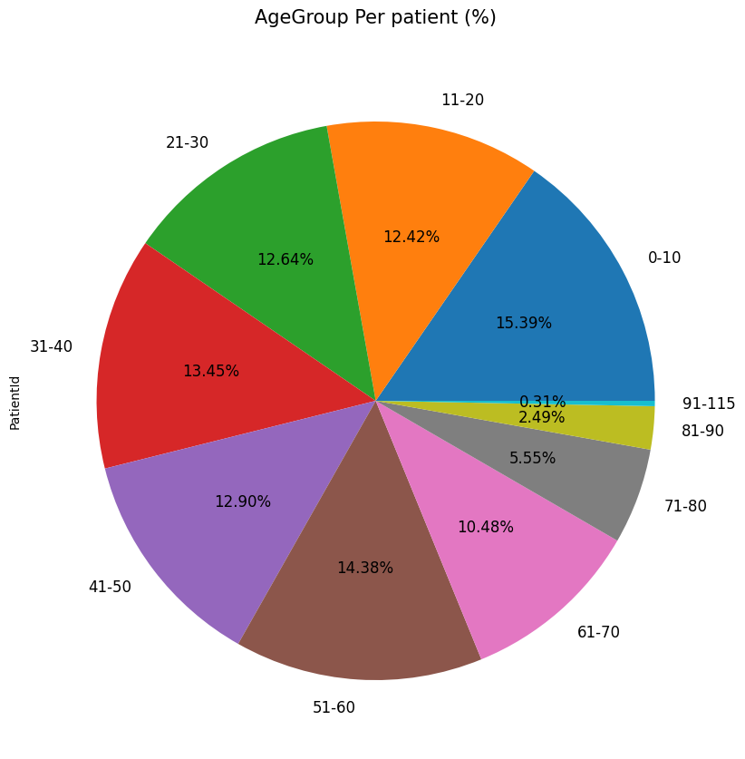

```python
numberOfPatientsByCol(df, 'AgeGroup')
```

| Showed_up AgeGroup | Yes | No |
| --- | --- | --- |
| 0-10 | 79.30 | 20.70 |
| 11-20 | 74.75 | 25.25 |
| 21-30 | 75.38 | 24.62 |
| 31-40 | 78.53 | 21.47 |
| 41-50 | 80.10 | 19.90 |
| 51-60 | 82.63 | 17.37 |
| 61-70 | 85.27 | 14.73 |
| 71-80 | 84.46 | 15.54 |
| 81-90 | 84.00 | 16.00 |
| 91-115 | 79.87 | 20.13 |

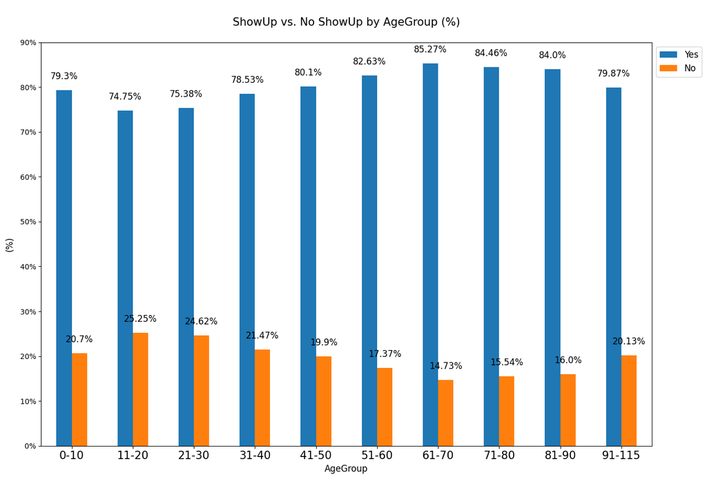

```python
# Visualize no showup and show up by age group using bar chart
generateBarChartByShowup(df, 'AgeGroup', figsize=(15,10))
```

#### 3. Scholarship

```
Scholarship
No     90.17
Yes     9.83
Name: count, dtype: float64
```

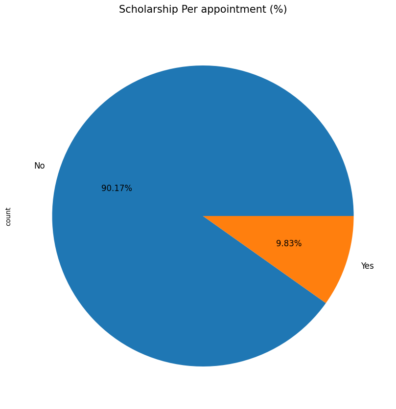

```python
generatePieChartAppointmentByCol(df, 'Scholarship')
```

| Scholarship | PatientId |
| --- | --- |
| No | 90.71 |
| Yes | 9.29 |

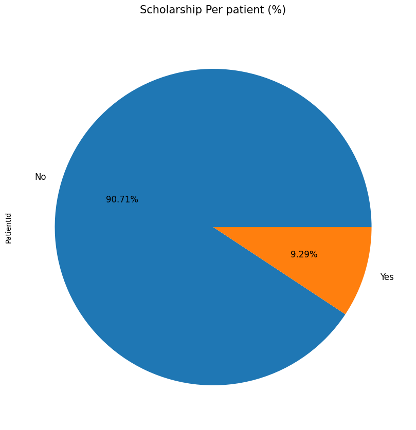

```python
numberOfPatientsByCol(df, 'Scholarship')
```

| Showed_up Scholarship | Yes | No |
| --- | --- | --- |
| No | 80.19 | 19.81 |
| Yes | 76.26 | 23.74 |

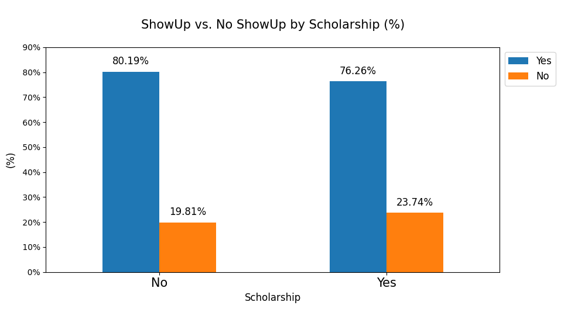

```python
generateBarChartByShowup(df, 'Scholarship')
```

#### 4. Hypertension

```
Hypertension
No     80.28
Yes    19.72
Name: count, dtype: float64
```

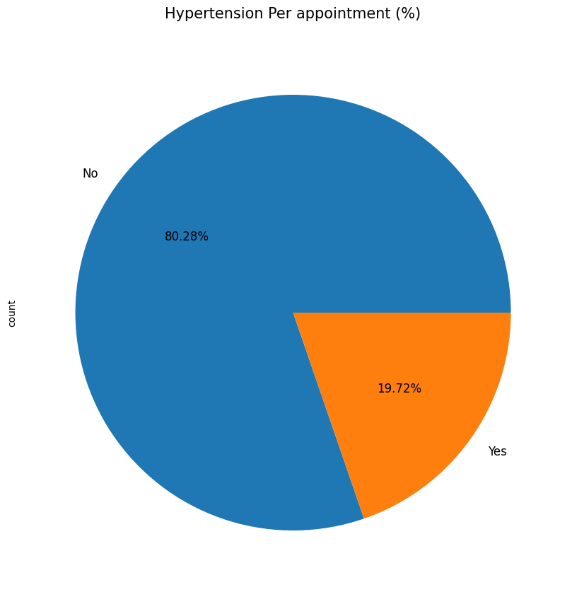

```python
generatePieChartAppointmentByCol(df, 'Hypertension')
```

| Hypertension | PatientId |
| --- | --- |
| No | 80.35 |
| Yes | 19.65 |

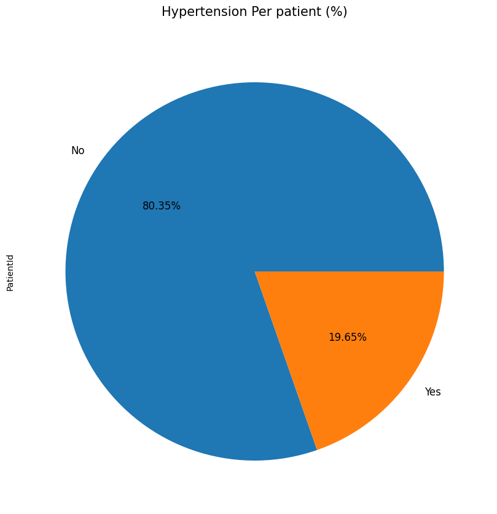

```python
# Number of patients by percentage
numberOfPatientsByCol(df, 'Hypertension')
```

| Showed_up Hypertension | Yes | No |
| --- | --- | --- |
| No | 79.1 | 20.9 |
| Yes | 82.7 | 17.3 |

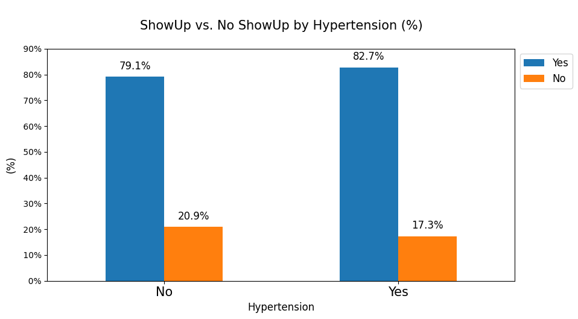

```python
# Visualize no showup and show up by hypertension using bar chart
generateBarChartByShowup(df, 'Hypertension')
```

#### 5. Diabetes

```
Diabetes
No     92.81
Yes     7.19
Name: count, dtype: float64
```

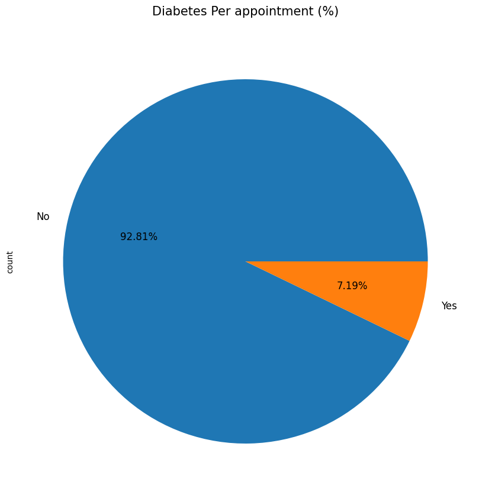

```python
# Number of patients by percentage
generatePieChartAppointmentByCol(df, 'Diabetes')
```

| Diabetes | PatientId |
| --- | --- |
| No | 92.91 |
| Yes | 7.09 |

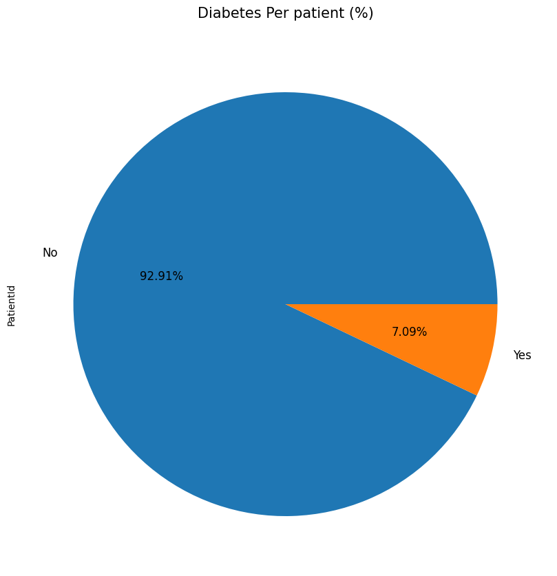

```python
# Number of patients by percentage
numberOfPatientsByCol(df, 'Diabetes')
```

| Showed_up Diabetes | Yes | No |
| --- | --- | --- |
| No | 79.64 | 20.36 |
| Yes | 82.00 | 18.00 |

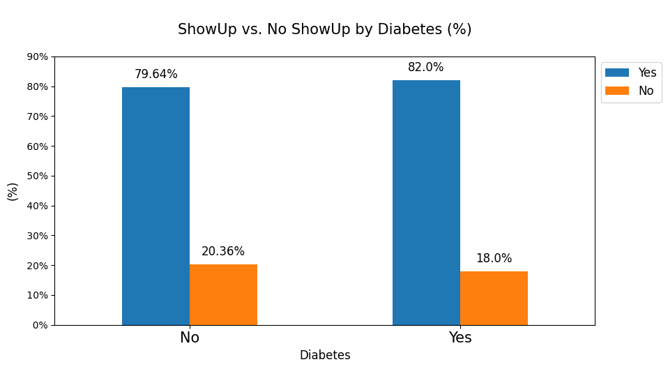

```python
# Visualize no showup and show up by diabetes using bar chart
generateBarChartByShowup(df, 'Diabetes')
```

#### 6. Neighbourhood

```
Neighbourhood
JARDIM CAMBURI       19.02
MARIA ORTIZ          14.31
RESISTÊNCIA          10.92
JARDIM DA PENHA       9.56
ITARARÉ               8.66
CENTRO                8.22
TABUAZEIRO            7.72
SANTA MARTHA          7.72
JESUS DE NAZARETH     7.03
BONFIM                6.84
Name: count, dtype: float64
```

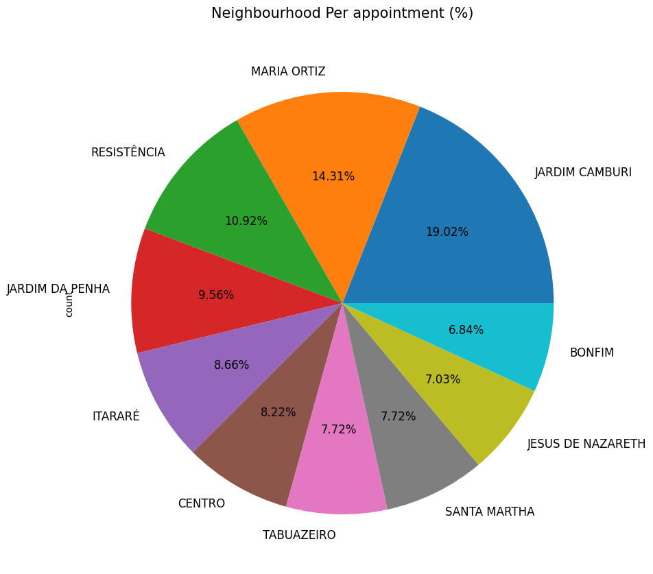

```python
# Number of patients by percentage
generatePieChartAppointmentByCol(df_top10_neighborhood, 'Neighbourhood')
```

| Neighbourhood | PatientId |
| --- | --- |
| BONFIM | 7.03 |
| CENTRO | 8.13 |
| ITARARÉ | 9.30 |
| JARDIM CAMBURI | 18.25 |
| JARDIM DA PENHA | 10.48 |
| JESUS DE NAZARETH | 6.25 |
| MARIA ORTIZ | 14.53 |
| RESISTÊNCIA | 10.33 |
| SANTA MARTHA | 7.61 |
| TABUAZEIRO | 8.08 |

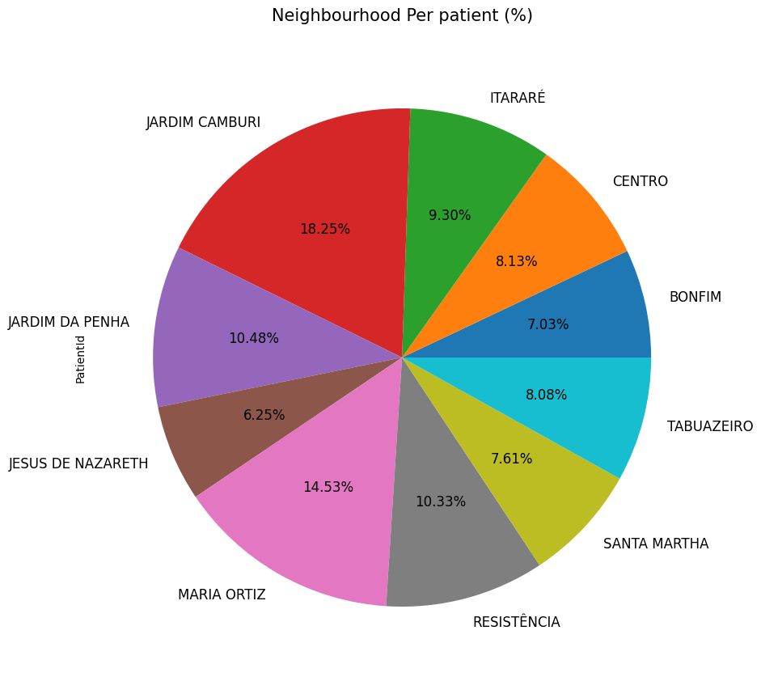

```python
# Number of patients by percentage
numberOfPatientsByCol(df_top10_neighborhood, 'Neighbourhood')
```

| Showed_up Neighbourhood | Yes | No |
| --- | --- | --- |
| BONFIM | 80.17 | 19.83 |
| CENTRO | 78.91 | 21.09 |
| ITARARÉ | 73.73 | 26.27 |
| JARDIM CAMBURI | 81.02 | 18.98 |
| JARDIM DA PENHA | 83.72 | 16.28 |
| JESUS DE NAZARETH | 75.60 | 24.40 |
| MARIA ORTIZ | 79.00 | 21.00 |
| RESISTÊNCIA | 79.55 | 20.45 |
| SANTA MARTHA | 84.16 | 15.84 |
| TABUAZEIRO | 81.70 | 18.30 |

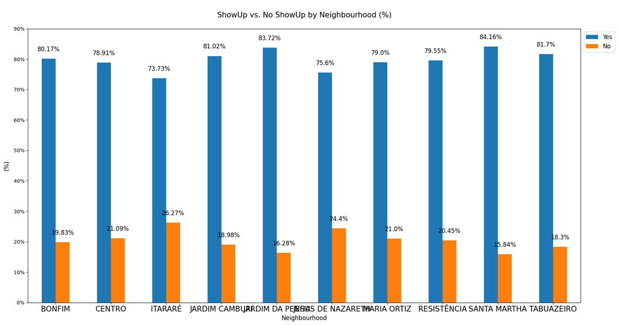

```python
# Visualize no showup and show up by diabetes using bar chart
generateBarChartByShowup(df_top10_neighborhood, 'Neighbourhood', figsize=(20,10))
```

#### 7. Alcoholism

```
Alcoholism
No     96.96
Yes     3.04
Name: count, dtype: float64
```

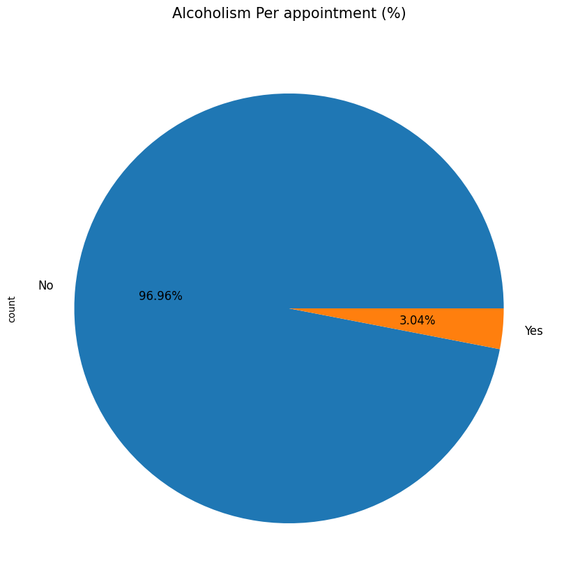

```python
# Number of patients by percentage
generatePieChartAppointmentByCol(df, 'Alcoholism')
```

| Alcoholism | PatientId |
| --- | --- |
| No | 97.58 |
| Yes | 2.42 |

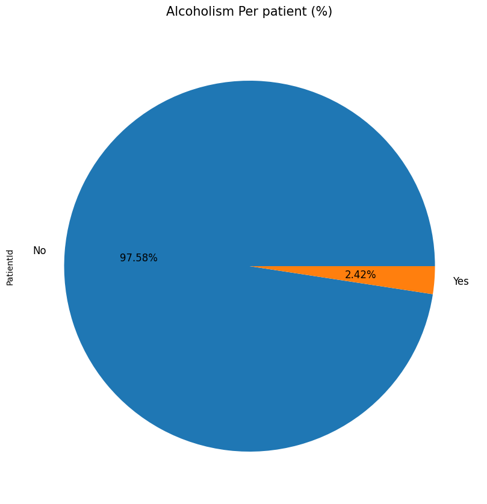

```python
# Number of patients by percentage
numberOfPatientsByCol(df, 'Alcoholism')
```

| Showed_up Alcoholism | Yes | No |
| --- | --- | --- |
| No | 79.81 | 20.19 |
| Yes | 79.85 | 20.15 |

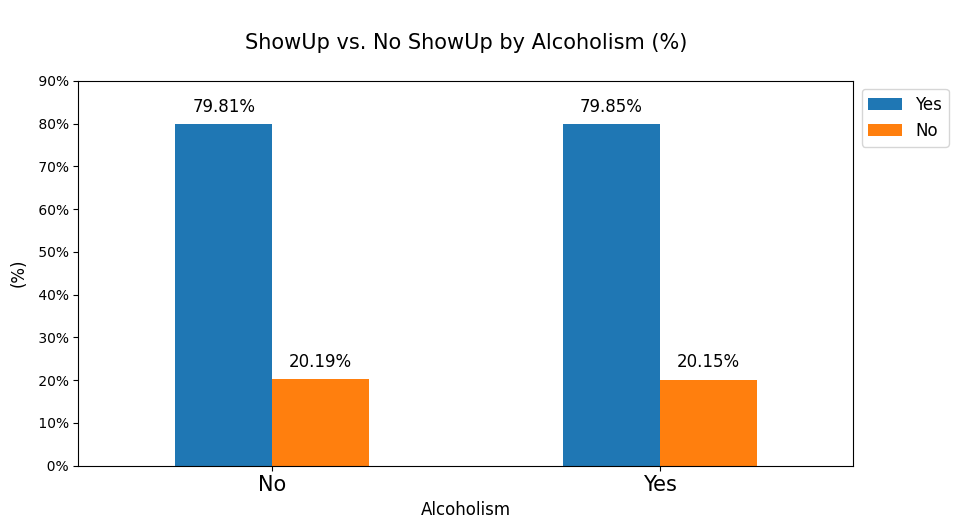

```python
# Visualize no showup and show up by alcoholism using bar chart
generateBarChartByShowup(df, 'Alcoholism')
```

#### 8. Handicap

| Showed_up Handicap | Yes | No |
| --- | --- | --- |
| Handicap L0 | 79.76 | 20.24 |
| Handicap L1 | 82.08 | 17.92 |
| Handicap L2 | 79.78 | 20.22 |
| Handicap L3 | 76.92 | 23.08 |
| Handicap L4 | 66.67 | 33.33 |

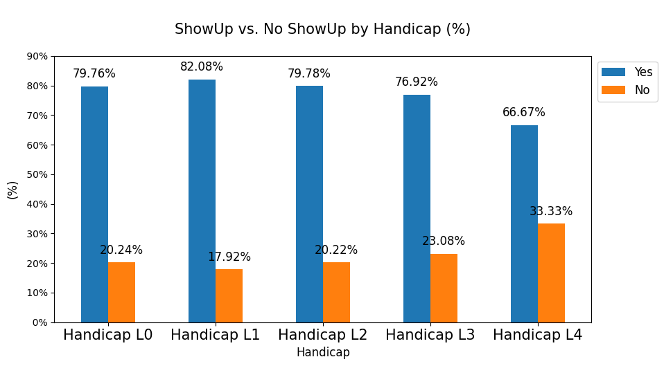

```python
# visualizing the appointment show-up rate by SMS_received
generateBarChartByShowup(df, 'Handicap')
```

#### 9. SMS_received

```
SMS_received
No     67.9
Yes    32.1
Name: count, dtype: float64
```

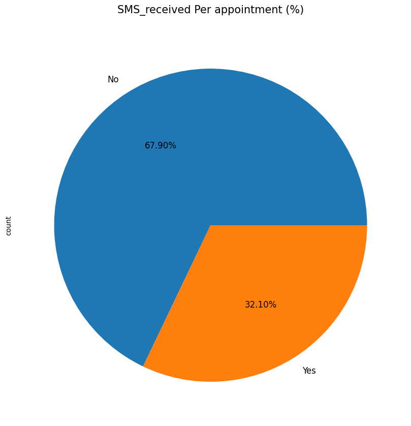

```python
# Number of patients by percentage
generatePieChartAppointmentByCol(df, 'SMS_received')
```

| SMS_received | PatientId |
| --- | --- |
| No | 63.59 |
| Yes | 36.41 |

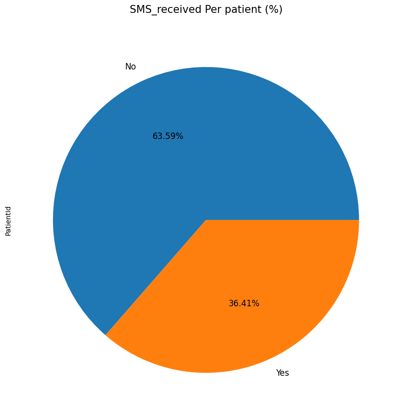

```python
# Number of patients by percentage
numberOfPatientsByCol(df, 'SMS_received')
```

| Showed_up SMS_received | Yes | No |
| --- | --- | --- |
| No | 83.30 | 16.70 |
| Yes | 72.43 | 27.57 |

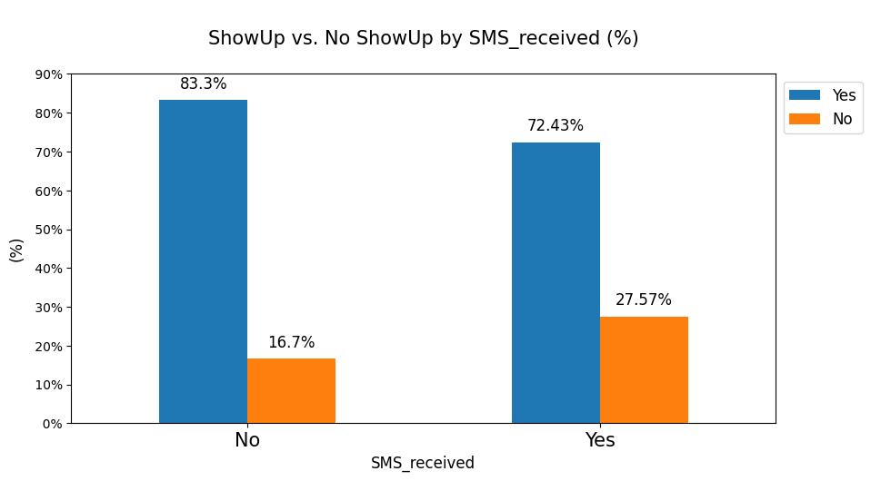

```python
# Visualize no showup and show up by SMS_received using bar chart
generateBarChartByShowup(df, 'SMS_received')
```

#### 10. Day of the Week of Appointment

```
DayOfWeek
Wednesday    23.40
Tuesday      23.20
Monday       20.55
Friday       17.21
Thursday     15.60
Saturday      0.04
Name: count, dtype: float64
```

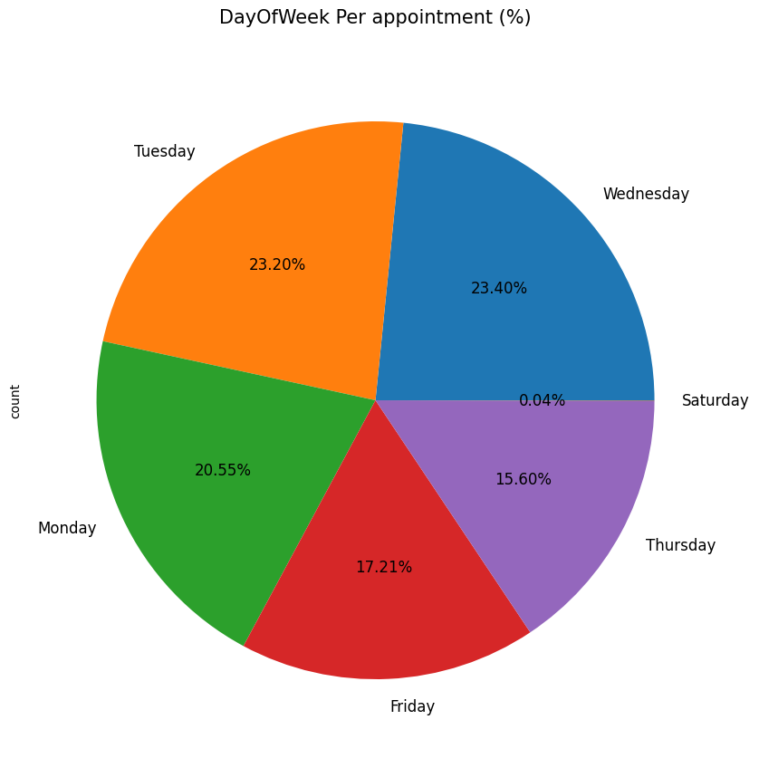

```python
# Number of appointments by day of week
generatePieChartAppointmentByCol(df, 'DayOfWeek')
```

| DayOfWeek | PatientId |
| --- | --- |
| Friday | 17.28 |
| Monday | 20.52 |
| Saturday | 0.04 |
| Thursday | 16.29 |
| Tuesday | 22.99 |
| Wednesday | 22.88 |

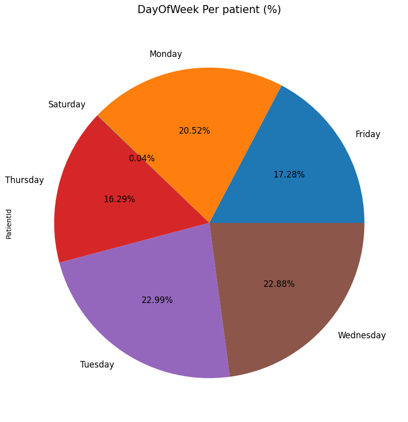

```python
# Number of patients by percentage by day of week
numberOfPatientsByCol(df, 'DayOfWeek')
```

| Showed_up DayOfWeek | Yes | No |
| --- | --- | --- |
| Friday | 78.77 | 21.23 |
| Monday | 79.35 | 20.65 |
| Saturday | 76.92 | 23.08 |
| Thursday | 80.65 | 19.35 |
| Tuesday | 79.91 | 20.09 |
| Wednesday | 80.31 | 19.69 |

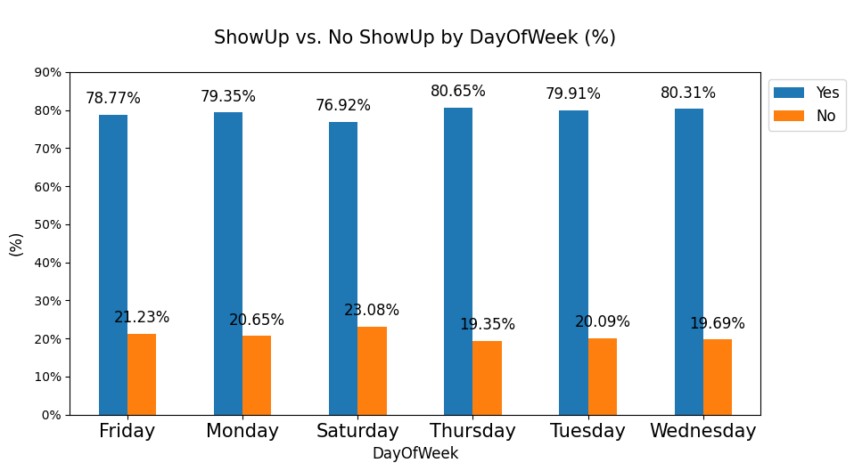

```python
# Visualize no showup and show up by day of week using bar chart
generateBarChartByShowup(df, 'DayOfWeek')
```

#### 12. Among the missed appointments, what is the percentage breakdown between recurring patients and new patients?

```python
# Among the missed appointments, what is the percentage breakdown between recurring patients and new patients?
# Check if there are appointments and patients to avoid division by zero
if df_no_showup['AppointmentID'].nunique() == 0 or df_no_showup['PatientId'].nunique() == 0:
    print("No appointments or patients available.")
else:
    # Calculate the percentage of new and recurring patients
    new_patient_percentage = np.round(df_no_showup['PatientId'].nunique() / df_no_showup['AppointmentID'].nunique() * 100, 2)
    rec_patient_percentage = 100 - new_patient_percentage

    # Display the results using f-strings for a cleaner output
    print(f'New clients(%): {new_patient_percentage}%\nRecurring clients(%): {rec_patient_percentage}%')
```

```
New clients(%): 79.14%
Recurring clients(%): 20.86%
```

As indicated in the cell above, the breakdown reveals that new patients constitute 79.15%, while recurring patients make up 20.85%. It's essential to emphasize that recurring patients, though inherently a subset of new patients, are categorized as such when they fail to attend appointments more than once. This nuanced definition ensures a comprehensive understanding of patient engagement.

#### 13. What is the percentage of missed appointments by SMS_received and Alcoholism?

| Alcoholism SMS_received | No | Yes |
| --- | --- | --- |
| No | 16.65 | 16.50 |
| Yes | 10.09 | 13.36 |

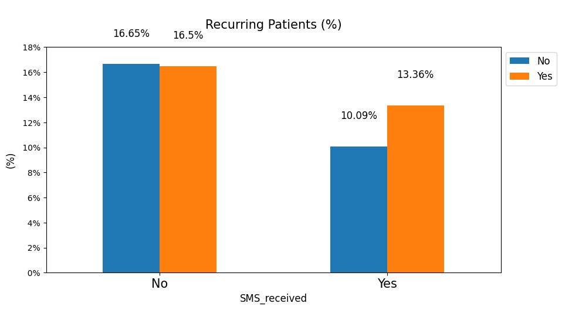

```python
#### 13. What is the percentage of missed appointments by SMS_received and Alcoholism?
recurringPatientPerBy2Cols(df_no_showup, 'SMS_received', 'Alcoholism')
```

| Alcoholism SMS_received | No | Yes |
| --- | --- | --- |
| No | 96.81 | 3.19 |
| Yes | 97.17 | 2.83 |

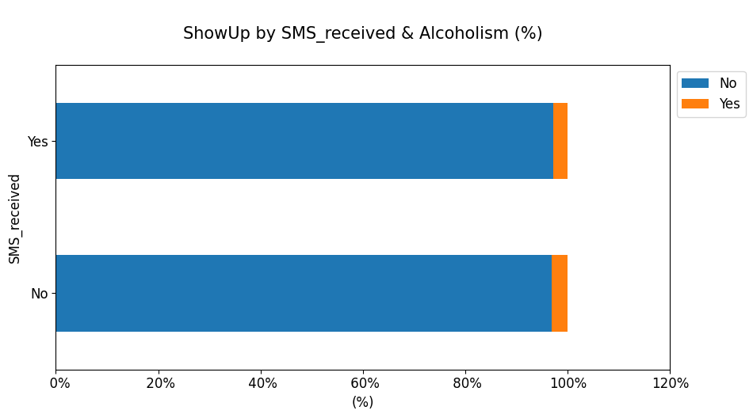

```python
#### 13. What is the percentage of missed appointments by SMS_received and Alcoholism?
showUpBy2Cols(df_no_showup, 'SMS_received', 'Alcoholism')
```

Examining the No ShowUp (%) chart provides notable insights:

SMS Received: A substantial majority (97.17%) of NoShow appointments, where patients received an SMS reminder, is observed among individuals without a history of Alcoholism.

No SMS Received: Similarly, the greatest proportion (96.81%) of NoShow appointments without an SMS reminder is found among patients who do not have a history of Alcoholism.

Shifting our focus to the Recurring Patients (%) chart:

SMS Received: Interestingly, the highest percentage (13.36%) of recurring patients who received an SMS reminder is noted among patients with a history of Alcoholism.

No SMS Received: Conversely, the highest percentage (16.64%) of recurring patients not receiving an SMS reminder is observed among patients without a history of Alcoholism.

These findings emphasize the influence of Alcoholism status on appointment attendance trends, both in the context of SMS reminders and recurring patient behavior.

#### 14. What is the percentage of missed appointments per SMS_received and Handicap?

[output not shown]

[figure not shown]

```python
#### 14. What is the percentage of missed appointments by SMS_received and Handicap?
recurringPatientPerBy2Cols(df_no_showup, 'SMS_received', 'Handicap')
```

[output not shown]

[figure not shown]

```python
#### 14. What is the percentage of missed appointments by SMS_received and Handicap?
showUpBy2Cols(df_no_showup, 'SMS_received', 'Handicap')
```

Analyzing the No ShowUp (%) chart yields insightful patterns:

SMS Received: The predominant majority (98.62%) of NoShow appointments, where patients received an SMS reminder, corresponds to individuals without a Handicap condition.

Exploring the Recurring Patients (%) chart uncovers further nuances:

SMS Received: Remarkably, the highest percentage (28.57%) of recurring patients who received an SMS reminder is observed among patients with Handicap L2 condition.

These findings emphasize the distinctive impact of Handicap conditions on appointment behavior, showcasing the need for personalized healthcare strategies tailored to patients with varying levels of Handicap.

#### 15. What is the percentage of missed appointments by SMS_received and Diabetes?

| Diabetes SMS_received | No | Yes |
| --- | --- | --- |
| No | 16.86 | 13.88 |
| Yes | 10.25 | 9.01 |

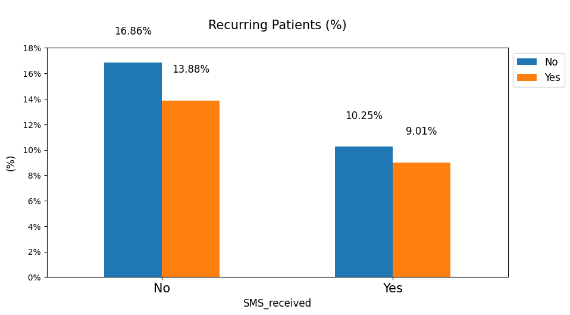

```python
#### 15. What is the percentage of missed appointments by SMS_received and Diabetes?
recurringPatientPerBy2Cols(df_no_showup, 'SMS_received', 'Diabetes')
```

| Diabetes SMS_received | No | Yes |
| --- | --- | --- |
| No | 92.93 | 7.07 |
| Yes | 94.44 | 5.56 |

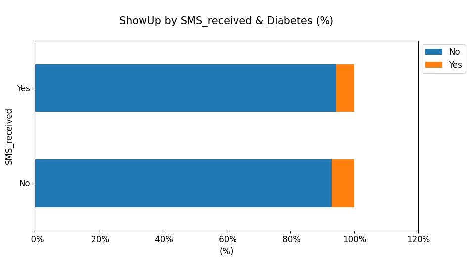

```python
#### 15. What is the percentage of missed appointments by SMS_received and Diabetes?
showUpBy2Cols(df_no_showup, 'SMS_received', 'Diabetes')
```

Analyzing the No ShowUp (%) chart reveals insightful patterns:

SMS Received:

- The majority (94.44%) of NoShow appointments with patients receiving an SMS reminder is observed among those without diabetes.

No SMS Received:

- Similarly, the highest proportion (92.93%) of NoShow appointments without an SMS reminder is evident among patients without diabetes.

Turning our attention to the Recurring Patients (%) chart:

SMS Received:

- Notably, the highest percentage (10.25%) of recurring patients receiving an SMS reminder is found among patients without diabetes.

No SMS Received:

- Conversely, the highest percentage (16.84%) of recurring patients not receiving an SMS reminder is observed among patients without diabetes. These findings shed light on the nuanced relationship between SMS reminders, diabetes status, and recurring patient behavior.

#### 16. What is the percentage of missed appointments by SMS_received and Day of week?

| DayOfWeek SMS_received | Friday | Monday | Saturday | Thursday | Tuesday | Wednesday |
| --- | --- | --- | --- | --- | --- | --- |
| No | 10.75 | 7.45 | 0.0 | 7.29 | 10.31 | 11.09 |
| Yes | 0.70 | 3.64 | 0.0 | 1.89 | 5.10 | 4.07 |

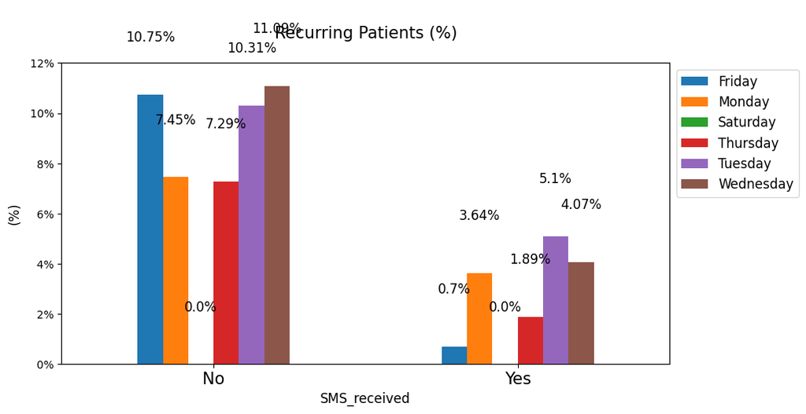

```python
#### 16. What is the percentage of missed appointments by SMS_received and Day of week?
recurringPatientPerBy2Cols(df_no_showup, 'SMS_received', 'DayOfWeek')
```

| DayOfWeek SMS_received | Friday | Monday | Saturday | Thursday | Tuesday | Wednesday |
| --- | --- | --- | --- | --- | --- | --- |
| No | 23.07 | 21.85 | 0.05 | 15.65 | 17.95 | 21.43 |
| Yes | 11.70 | 19.94 | 0.03 | 14.06 | 29.66 | 24.60 |

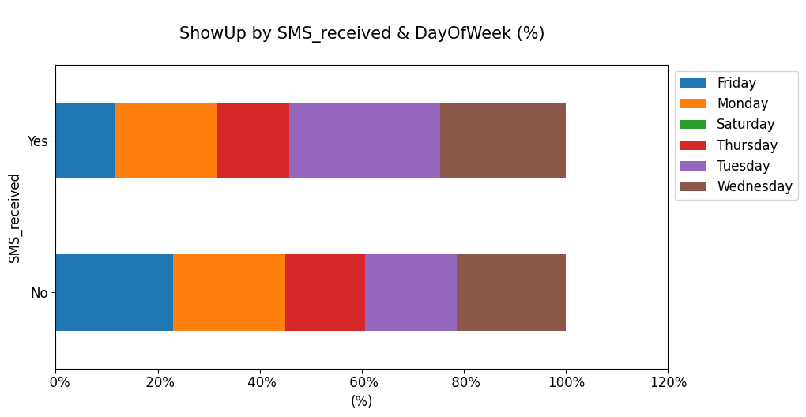

```python
#### 16. What is the percentage of missed appointments by SMS_received and Day of week?
showUpBy2Cols(df_no_showup, 'SMS_received', 'DayOfWeek')
```

Analyzing the No ShowUp (%) chart provides intriguing observations:

SMS Received: The most substantial proportion (29.66%) of NoShow appointments, where patients received an SMS reminder, is associated with appointments scheduled for Tuesdays.

No SMS Received: Conversely, the highest percentage (23.08%) of NoShow appointments without an SMS reminder is linked to appointments scheduled for Fridays.

Now, exploring the Recurring Patients (%) chart yields additional insights:

SMS Received: Notably, the highest percentage (5.10%) of recurring patients receiving an SMS reminder is observed for appointments scheduled on Tuesdays.

No SMS Received: In contrast, the highest percentage (11.10%) of recurring patients not receiving an SMS reminder is connected to appointments scheduled on Wednesdays.

These findings illuminate the nuanced relationship between appointment scheduling, SMS reminders, and recurring patient behavior, offering valuable insights for improved appointment management strategies.

#### 17. What is the percentage of missed appointments by SMS_received and Handicap?

| Handicap SMS_received | Handicap L0 | Handicap L1 | Handicap L2 | Handicap L3 | Handicap L4 |
| --- | --- | --- | --- | --- | --- |
| No | 16.30 | 34.17 | 20.00 | 0.0 | NaN |
| Yes | 10.14 | 12.70 | 28.57 | 0.0 | 0.0 |

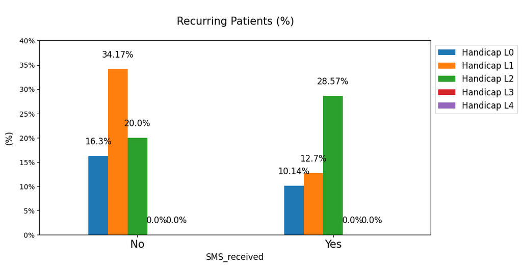

```python
#### 17. What is the percentage of missed appointments by SMS_received and Handicap?
recurringPatientPerBy2Cols(df_no_showup, 'SMS_received', 'Handicap')
```

| Handicap SMS_received | Handicap L0 | Handicap L1 | Handicap L2 | Handicap L3 | Handicap L4 |
| --- | --- | --- | --- | --- | --- |
| No | 97.83 | 1.91 | 0.24 | 0.02 | 0.00 |
| Yes | 98.62 | 1.29 | 0.07 | 0.01 | 0.01 |

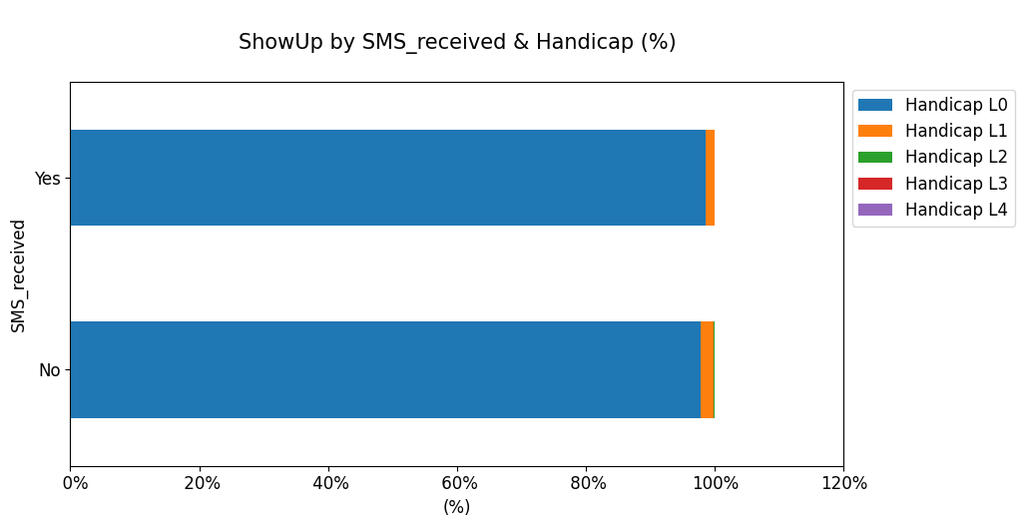

```python
#### 17. What is the percentage of missed appointments by SMS_received and Handicap?
showUpBy2Cols(df_no_showup, 'SMS_received', 'Handicap')
```

Upon reviewing the No ShowUp (%) chart, notable patterns emerge:

SMS Received: A significant majority (98.62%) of NoShow appointments, where patients received an SMS reminder, is observed among individuals without a Handicap condition.

SMS Received: Remarkably, the highest percentage (28.57%) of recurring patients receiving an SMS reminder is identified among patients with Handicap L2 condition.

These findings underscore the nuanced impact of Handicap conditions on appointment attendance trends, shedding light on the importance of tailored strategies for different patient demographics.

#### 18. What is the percentage of missed appointments by Gender and Diabetes?

| Diabetes Gender | No | Yes |
| --- | --- | --- |
| Female | 21.12 | 21.73 |
| Male | 20.64 | 14.29 |

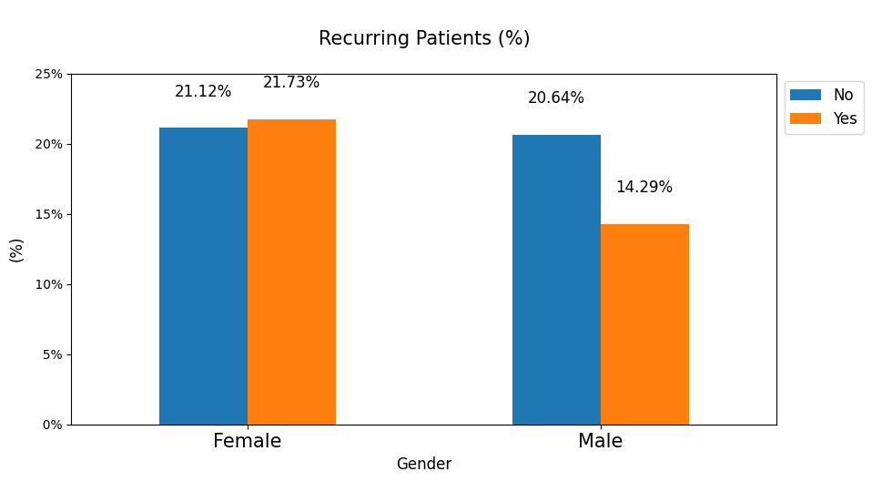

```python
#### 18. What is the percentage of missed appointments by Gender and Diabetes?
recurringPatientPerBy2Cols(df_no_showup, 'Gender', 'Diabetes')
```

| Diabetes Gender | No | Yes |
| --- | --- | --- |
| Female | 93.03 | 6.97 |
| Male | 94.65 | 5.35 |

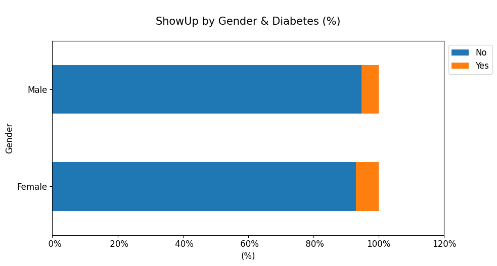

```python
#### 18. What is the percentage of missed appointments by Gender and Diabetes?
showUpBy2Cols(df_no_showup, 'Gender', 'Diabetes')
```

Analyzing the No ShowUp (%) chart uncovers significant observations:

Females: Among female patients, 6.97% of 'NoShowUp' appointments are attributed to those experiencing diabetes.

Males: For male patients, 5.35% of 'NoShowUp' appointments are recorded among those with diabetes.

Shifting our attention to the Recurring Patients (%) chart reveals further insights:

Females: Notably, the percentage of recurring female patients with diabetes (21.73%) surpasses those without diabetes (21.1%).

These findings highlight gender-specific patterns in both 'NoShowUp' appointments and recurring patient behavior, emphasizing the importance of tailoring healthcare strategies based on gender and diabetic status.

## Conclusions

To facilitate a comprehensive exploration of the dataset, the analysis was centered around ten pivotal questions. These questions, outlined below, guided the exploration, and the subsequent findings were elucidated through visuals for clarity.

Questions:

1. What are the percentages of patients who showed up and those who did not?
2. Which gender shows up for appointments the most?
3. Do patients with handicaps show up, and what is their show-up rate compared to patients without handicaps?
4. Do alcoholic patients show up for their medical appointments, and what is their show-up rate compared to non-alcoholic patients?
5. Do diabetic patients show up for medical appointments, and what is their show-up rate compared to patients without diabetes?
6. Do scholarship-holding patients show up for medical appointments, and what is their show-up rate compared to patients without scholarships?
7. Do patients who receive SMS show up for medical appointments, and what is their show-up rate compared to patients who do not receive SMS?
8. Do patients with hypertension show up for medical appointments, and what are their show-up rates compared to patients without hypertension?
9. Who, between seniors and youth, is more concerned about their health?
10. What are the correlations between relevant variables?

```python
# Import nbconvert and export the notebook to HTML
import nbconvert
```

```python
# Running this cell will execute a bash command to convert this notebook to an .html file
!python -m nbconvert --to html Investigate_a_Dataset.ipynb
```

```
[NbConvertApp] Converting notebook Investigate_a_Dataset.ipynb to html
[NbConvertApp] WARNING | Alternative text is missing on 40 image(s).
[NbConvertApp] Writing 2674658 bytes to Investigate_a_Dataset.html
```